# UNICEF

Child Dependency Quatro Report - 2023

This Dashboard compares the Child Dependency Ratio with Gross National Income, Population and GDP per Capita.

Author

Shakthi Rishi R V - 22264249 - DCU

Published

17-04-2023

## Executive Summary

All the data used in developing this report is from **UNICEF**.

### Key Highlights

- There is a **Correlation** between the Child Dependency Ratio and Population, Gross National Income & GDP per Capita.
- As the **population grows**, the **child dependency ratio reduces** which clearly indicates that there are more adults now than before to take care of children in a macro view.
- The **child dependency ratio decreases** with **increase in Gross National Income, GDP per Capita and Population**. Now, it helps to understand that the individual Income of people also plays a crucial factor alongside population.
- The **more the income of people** across population growth, the **lesser the child dependency** is. This also means that the adult individuals are now **more financially stable** and capable of taking responsibility for more children than before, which reduces the child dependency significantly.
- Precisely, countries in *Africa* tend to have **Higher** Child Dependency comparitively, the possible reasons could be their:

  **- Low GDP per Capita**

  **- Slow Economic Growth of the Nation**

  **- Lesser Gross National Income**

Check out the Tableau version of this report - [Click Here](https://public.tableau.com/views/ChildDependencyDashboard/Dshboard2?:language=en-GB&publish=yes&:display_count=n&:origin=viz_share_link)

## The Insightful Story

#### Child Dependency across the World

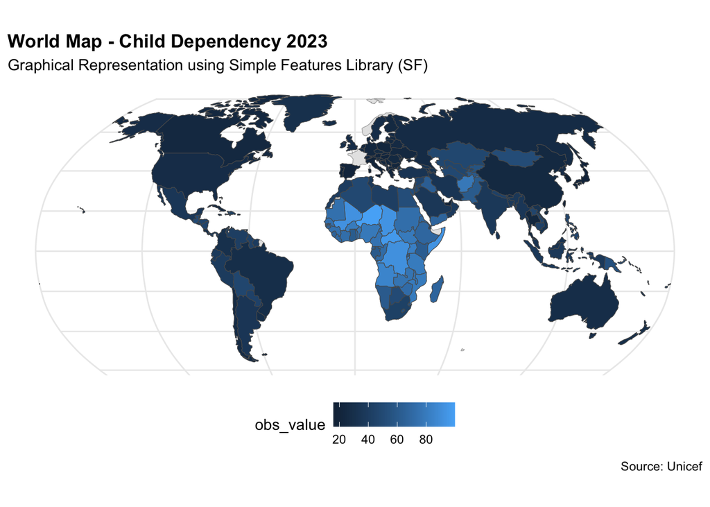

- As per the above World Map, it is noted that most countries in *Africa* tend to have **High** Child Dependency and countries like *South Korea, Japan, Singapore, UAE, Taiwan etc.* have **Low** Child Dependency.
- Countries in *Africa* tend to have **Higher** Child dependency ratios Comparitively (from Below Bar Chart).

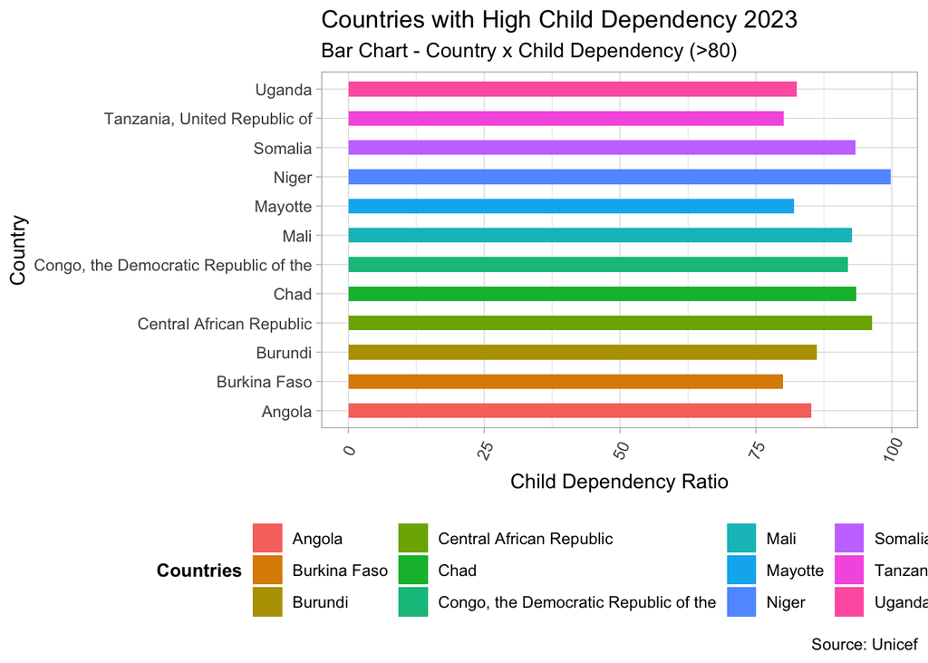

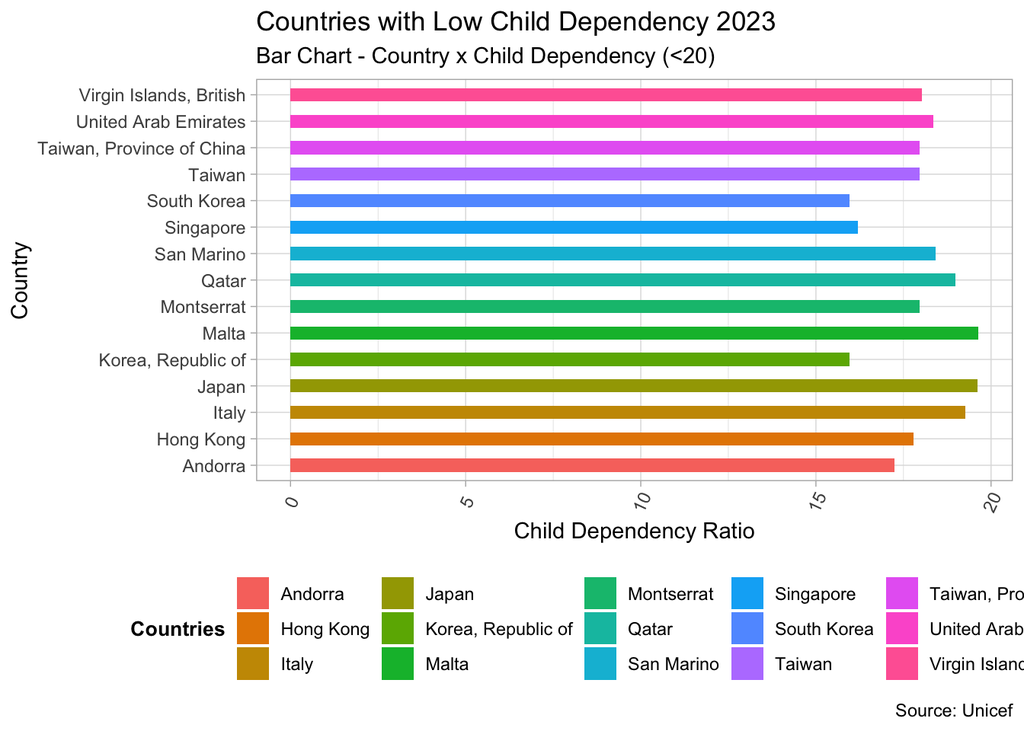

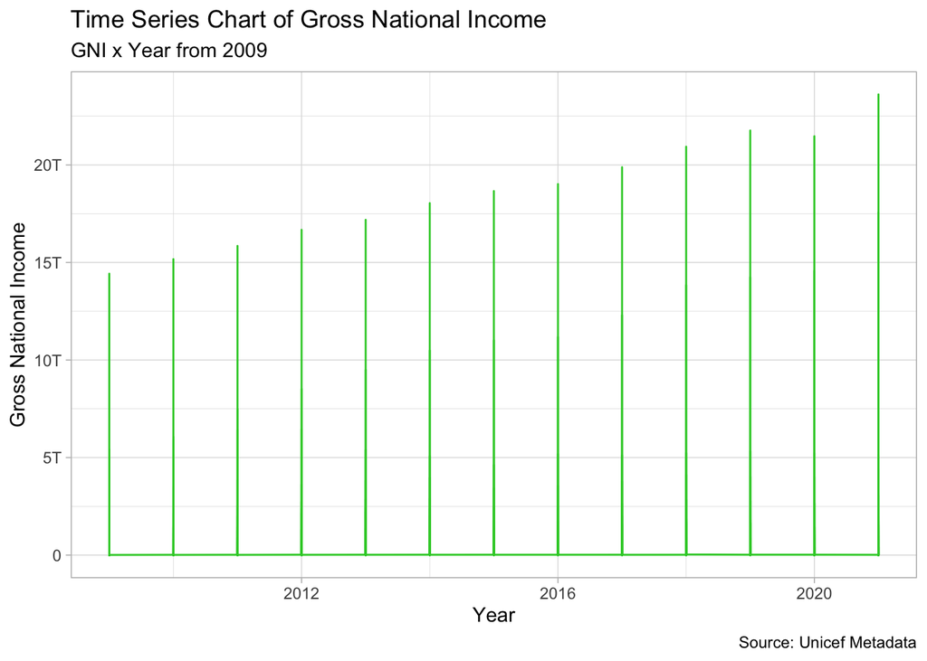

**Insights:**

- GNI steadily **increases** over the years.
- Child Dependency reduces with Increase in Gross National Income.

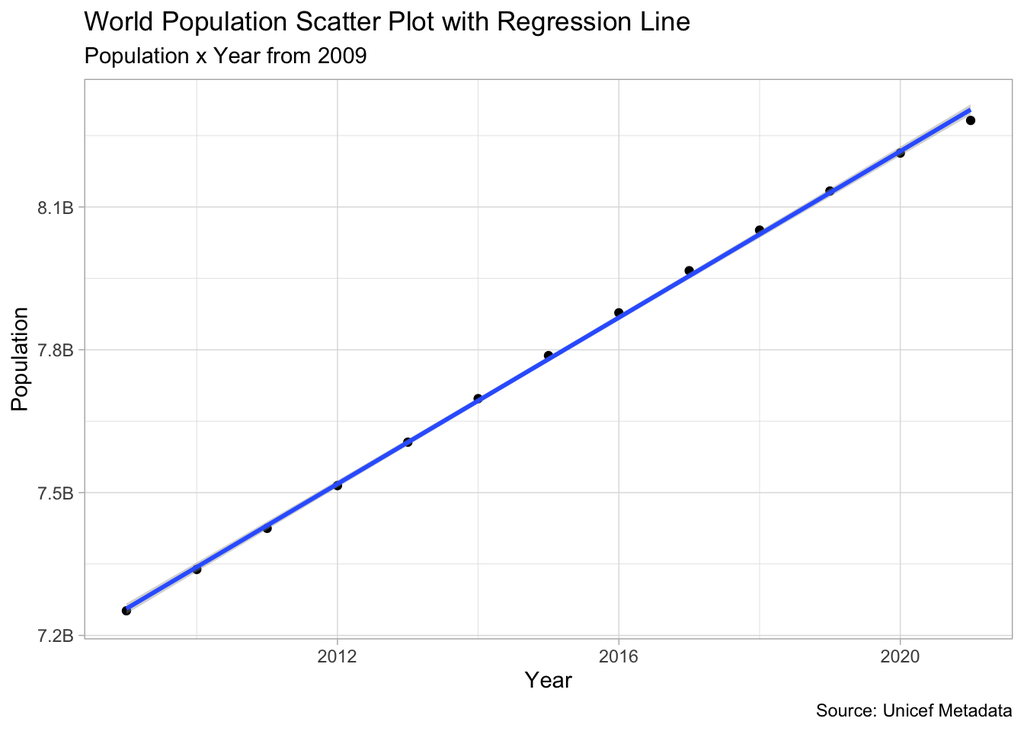

**Insights:**

- Population **increases** rapidly over the years.

#### GDP Per Capita

- Sum of gross value added by all resident producers in the economy plus any product taxes (less subsidies) not included in the valuation of output, divided by mid-year population.

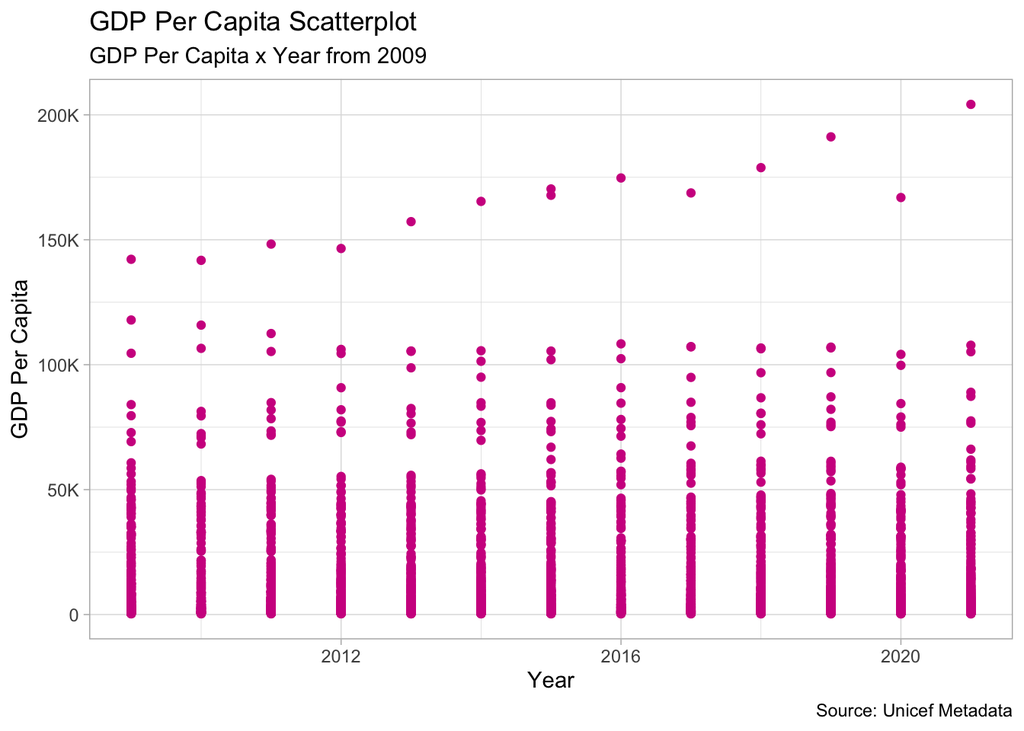

**Insights:**

- As **GDP Per Capita Increases** over the years and **Child Dependency Reduces**.